# Colocalization Analysis

## Overview

This tutorial walks through a complete **cell type colocalization analysis** using scSpatial. The workflow has three steps:

1. **Compute colocalization matrices** — for every cell, quantify how close it is to each reference cell type using a Gaussian density field.
2. **Plot per-slide heatmaps** — aggregate colocalization values by cell type and visualize them as heatmaps for each tissue slide.
3. **Plot average-across-slides heatmaps** — summarize the pattern across all slides, and optionally highlight per-slide deviations.

## Prerequisites

```r
# Install scSpatial (if not yet installed)
# devtools::install_github("Yuqing66/scSpatial")

# ComplexHeatmap is needed for heatmap plotting (Bioconductor)
if (!requireNamespace("ComplexHeatmap", quietly = TRUE)) {
  BiocManager::install("ComplexHeatmap")
}
```

```r
library(Seurat)
library(scSpatial)
library(ggplot2)
library(ggforce)
library(dplyr)
library(tibble)
```

## Load your data

scSpatial works with Seurat objects that contain spatial imaging data (e.g., seqFISH, MERFISH, Xenium). Each tissue slide should be stored as a separate image in `srt@images`.

```r
srt <- readRDS("~/Downloads/seqFISH_vignettes.rds")

# Check which images (slides) are available
names(srt@images)
```

```
#>  [1] "UV109fov1" "UV109fov2" "UV253fov1" "UV253fov2" "UV238fov1" "UV238fov2" "UV239fov1" "UV239fov2" "VB268fov1" "VB268fov2"
#> [11] "UV243fov1" "UV260fov1" "UV260fov2"
```

```r
# e.g. [1] "UV109fov1" "UV109fov2" "UV253fov1" ...
```

### Choose the cell type column

Identify which metadata column contains the cell type annotations you want to use for colocalization:

```r
# Set the column name you want to use
celltype.col <- "subCellType.pub3.1.MCCD14"  # <-- change this to your column name
```

## Step 1: Compute colocalization matrices

`calcColocalization()` iterates over every image and every reference cell type. For each reference type it builds a Gaussian density field from the reference cell positions, then evaluates that field at every cell location. The result is a data.frame with one row per cell and one column per reference cell type.

The `sd` parameter controls the spatial smoothing radius — larger values consider a wider neighborhood. Use `ImageDimPlot.sizeGuide()` to choose an appropriate value for your data.

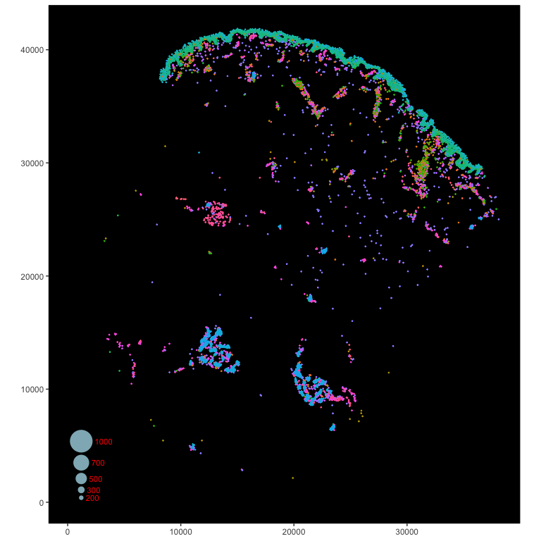

```r
# Visualize circles of different radii to pick a good sd value
ImageDimPlot.sizeGuide(
  srt,
  fov      = names(srt@images)[1],
  group.by = celltype.col,
  radii    = c(200, 300, 500, 700, 1000)
)
```

```r
coloc.values <- calcColocalization(
  srt,
  celltype.col = celltype.col,
  sd           = 500,           # adjust based on sizeGuide
  scale.factor = 10000
)
```

```r
# Inspect the result
dim(coloc.values)
```

```
#> [1] 137749     48
```

```r
coloc.values[1:5, 1:5]
```

```
#>              DC1 DC2 pDC MC_CD14 LC
#> UV109fov1_69   0   0   0       0  0
#> UV109fov1_80   0   0   0       0  0
#> UV109fov1_90   0   0   0       0  0
#> UV109fov1_94   0   0   0       0  0
#> UV109fov1_96   0   0   0       0  0
```

Optionally save spatial value plots for each reference cell type:

```r
coloc.values <- calcColocalization(
  srt,
  celltype.col = celltype.col,
  sd           = 500,
  save.plots   = TRUE,
  plot.dir     = "colocalization_fields"
)
```

### Save / load results

Computing colocalization values can be time-consuming for large datasets. Save the result so you don’t have to recompute:

```r
write.csv(coloc.values, "colocalization_values.csv")
```

## Step 2: Compute and plot per-slide heatmaps

`calcColocalizationHeatmap()` aggregates the per-cell values into a cell type × cell type matrix for each slide. It supports three optional preprocessing steps:

- **merge.list**: merge related subtypes into a single label
- **rm.celltypes**: remove cell types from all slides
- **rm.celltypes.per.image**: remove cell types from specific slides (e.g., tissue structures not present in a given biopsy)

```r
heatmap.list <- calcColocalizationHeatmap(
  srt,
  coloc.values = coloc.values,
  celltype.col = celltype.col,

  # Optional: merge subtypes
  merge.list = list(
    CD4      = c("CD4", "CD4_CCL17", "CD4_CXCL13"),
    Pericyte = c("Pericyte", "Pericyte_activated"),
    EC       = c("EC", "EC_proliferating", "EC_immune_interactive")
  ),

  # Optional: remove from ALL slides
  rm.celltypes = c("MC_unk_1", "MC_unk_2", "Neutrophil"),

  # Optional: remove from specific slides
  rm.celltypes.per.image = list(
    UV109fov1 = c("KC_bulge", "B_cell"),
    UV109fov2 = c("KC_bulge", "B_cell"),
    UV243fov1 = c("KC_eccrine_glandular", "KC_eccrine_ductal")
  )
)

# Inspect: one entry per slide
names(heatmap.list)
```

```
#>  [1] "UV109fov1" "UV109fov2" "UV253fov1" "UV253fov2" "UV238fov1" "UV238fov2" "UV239fov1" "UV239fov2" "VB268fov1" "VB268fov2"
#> [11] "UV243fov1" "UV260fov1" "UV260fov2"
```

### Understanding the scaling

Each entry in `heatmap.list` contains two matrices:

- **`$heatmap`**: raw mean colocalization values per cell type pair (query row, reference column), plus an `"all"` row representing the overall mean across all cells regardless of type.
- **`$heatmap.scaled`**: a normalized version that removes the effects of cell type abundance and baseline field density, making values comparable across reference cell types.

The scaling works as follows for each reference column:

$$\text{scaled value} = \frac{\text{raw
value} - \text{mean(all cells)}}{\text{self-colocalization} -
\text{mean(all cells)}} \times 100$$

This sets two anchors: - **Self-colocalization = 100**: the reference cell type’s own colocalization with itself. - **Overall mean = 0** (`"all"` row): the average colocalization value across every cell in the image, regardless of type.

As a result, a scaled value of **50** means the query cell type is halfway between a random cell and the reference type itself. Values **above 100** are possible if a query type is spatially closer to the reference than the reference cells are to each other on average. Values **below 0** indicate spatial avoidance (the query type is further from the reference than a random cell would be). This normalization removes the influence of cell type abundance and field density, making colocalization directly comparable across reference types.

```r
# Example: first slide — scaled matrix
heatmap.list[[1]]$heatmap.scaled[1:5, 1:5]
```

```
#>                 DC1        DC2        pDC   MC_CD14        LC
#> DC1     100.0000000  55.563300   8.997740  76.96548 -20.67543
#> DC2      42.7513672 100.000000   8.762287  75.21534 -25.17796
#> pDC      36.8738313  46.687184 100.000000 121.62693 -41.72199
#> MC_CD14  27.6483148  34.612855  11.092658 100.00000 -28.25751
#> LC       -0.6671715  -6.577022  -6.719834 -15.89532 100.00000
```

### Plot per-slide heatmaps

Save each slide as a separate PDF:

```r
plotColocalizationHeatmap(
  heatmap.list,
  type       = "per.slide",
  cluster.by = "reference",
  file       = "heatmap_per_slide.pdf"
)
# Creates: heatmap_per_slide_UV109fov1.pdf, heatmap_per_slide_UV109fov2.pdf, ...
```

## Step 3: Plot average-across-slides heatmap

Average the scaled colocalization values across all slides to get the overall pattern.

### Clustering modes

The `cluster.by` parameter controls how cell types are ordered on the two axes of the heatmap. Rows are **query** cell types (whose colocalization is being measured) and columns are **reference** cell types (whose spatial field is being queried).

| `cluster.by` | Columns (reference) | Rows (query) | Best for |
| --- | --- | --- | --- |
| `"reference"` *(default)* | Hierarchically clustered | Mirrored to same order | Comparing how all cell types enrich near each reference type; diagonal self-enrichment is easy to read |
| `"query"` | Mirrored to same order | Hierarchically clustered | Grouping query types with similar colocalization fingerprints |
| `"both"` | Independently clustered | Independently clustered | Exploratory overview |
| `"none"` | Input order | Input order | Custom ordering |
| `"average.order"` | Fixed to average order | Fixed to average order | Applying a consistent layout across difference heatmaps |

For `"reference"` and `"query"` modes, the heatmap is largely square (no `"all"` row for `"query"` mode) and the shared order means the diagonal runs top-left to bottom-right, making self-colocalization easy to verify. These ordering modes are applied consistently across all heatmap `type`s (`"average"`, `"per.slide"`, and `"difference"`).

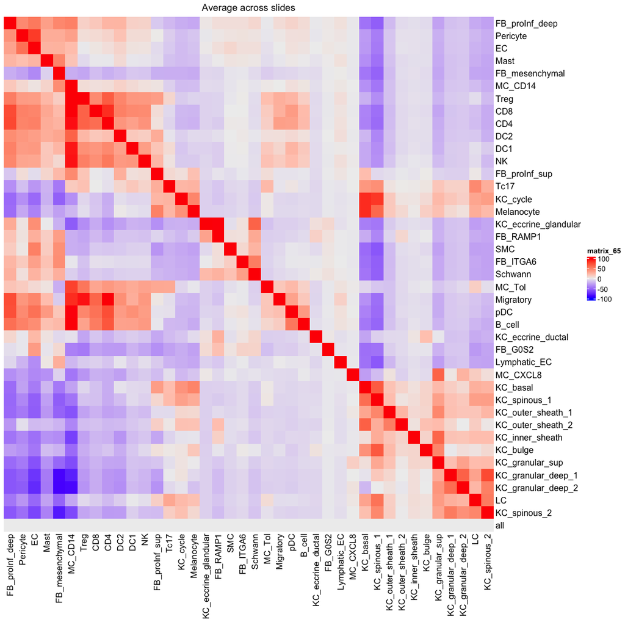

```r
# Default: cluster by reference, mirror order onto query axis
plotColocalizationHeatmap(
  heatmap.list,
  type       = "average",
  cluster.by = "reference"
)
```

```r
# Cluster by query cell types, mirror onto reference axis
plotColocalizationHeatmap(
  heatmap.list,
  type       = "average",
  cluster.by = "query"
)

# Cluster rows and columns independently
plotColocalizationHeatmap(
  heatmap.list,
  type       = "average",
  cluster.by = "both",
  file       = "heatmap_average_clusterBoth.pdf"
)
```

### Difference heatmaps: per-slide vs. average

Highlight what is unique about each slide by subtracting the cross-slide average:

```r
plotColocalizationHeatmap(
  heatmap.list,
  type       = "difference",
  cluster.by = "reference",
  file       = "heatmap_difference.pdf"
)
# Creates: heatmap_difference_UV109fov1_diff.pdf, etc.
```

## Working with the Returned Heatmap Objects

By default, `plotColocalizationHeatmap()` draws the heatmap(s) to the active graphics device or saves them to a PDF if `file` is provided. The function also returns the underlying `ComplexHeatmap::Heatmap` objects so you can manipulate them later.

- When `type = "average"`, it returns a single `Heatmap` object.
- When `type = "per.slide"` or `type = "difference"`, it returns a **named list** of `Heatmap` objects (one per slide).

If you provide a `file`, these objects are returned *invisibly* to prevent auto-printing to the console. If no `file` is specified, they are returned normally.

You can capture the returned objects to modify the plots further, extract the clustering dendrograms, or combine them with other plots:

```r
# Capture the list of Heatmap objects (without saving to PDF)
hmaps <- plotColocalizationHeatmap(heatmap.list, type = "per.slide")

# Draw a specific slide's heatmap later
ComplexHeatmap::draw(hmaps[["UV109fov1"]])

# Or capture the average Heatmap object
avg_hmap <- plotColocalizationHeatmap(heatmap.list, type = "average")
```

## Putting it all together

Here is the complete workflow in a compact script:

```r
library(Seurat)
library(scSpatial)

# ---- Load data ----
srt <- readRDS("path/to/seurat.rds")
celltype.col <- "CellType"

# ---- Step 1: Compute colocalization values ----
coloc.values <- calcColocalization(srt, celltype.col = celltype.col, sd = 500)

# ---- Step 2: Build heatmap matrices ----
heatmap.list <- calcColocalizationHeatmap(
  srt, coloc.values,
  celltype.col = celltype.col,
  merge.list = list(CD4 = c("CD4", "CD4_CCL17", "CD4_CXCL13")),
  rm.celltypes = c("Neutrophil"),
  rm.celltypes.per.image = list(UV109fov1 = c("B_cell"))
)

# ---- Step 3a: Per-slide heatmaps ----
plotColocalizationHeatmap(heatmap.list, type = "per.slide",
                          cluster.by = "reference",
                          file = "heatmap_per_slide.pdf")

# ---- Step 3b: Average heatmap ----
plotColocalizationHeatmap(heatmap.list, type = "average",
                          cluster.by = "reference",
                          file = "heatmap_average.pdf")

# ---- Step 3c: Difference heatmaps ----
plotColocalizationHeatmap(heatmap.list, type = "difference",
                          cluster.by = "reference",
                          file = "heatmap_difference.pdf")
```